# Ford GoBike System Data Deep Dive

## Dataset Overview

> The data consists of information on 174952 trips across the San Francesco Bay by bikers in the month of February 2019. The information in the dataset insclude, start and endtimes, gender of biker, birth year of biker, start and end coordinates, start and end station IDs, bike ID, duration of trips, whether or not a trip utilized bike-share through out or not age of bikers, start and end hours, period of day, day of week and distance covered in kilometers.

> The dataset, there were bikers above 70 years to a max of 141 (outliers). Since in reality it is near infeasible for such aged persons to ride bicycle's the dataset was filtered to capture only bikers 70 years old and less. The final dataset for the visualization containded information on 174377 trips.

```
<class 'pandas.core.frame.DataFrame'>
Int64Index: 174377 entries, 0 to 174951
Data columns (total 24 columns):
 #   Column                   Non-Null Count   Dtype
---  ------                   --------------   -----
 0   Unnamed: 0               174377 non-null  int64
 1   duration_sec             174377 non-null  int64
 2   start_time               174377 non-null  object
 3   end_time                 174377 non-null  object
 4   start_station_id         174377 non-null  float64
 5   start_station_name       174377 non-null  object
 6   start_station_latitude   174377 non-null  float64
 7   start_station_longitude  174377 non-null  float64
 8   end_station_id           174377 non-null  float64
 9   end_station_name         174377 non-null  object
```

[output cut: 16 more lines]

## Visualization 1: Pie Chart of Gender of Bikers

> This is a pie chart showing the gender of all the bikers in the bike-sharing system covering the greater San Francisco Bay area. From the chart, there are three gender categories; male, female and other which represent other bikers who didnot declared their gender or identify neither as a male or female. The chart reveales that the majority of bikers were males (74.6 %), followed by females (23.4 %) and other (2.1 %).

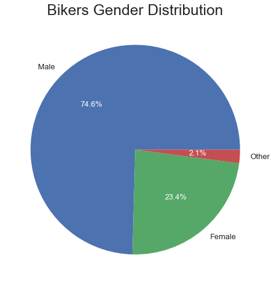

## Visualization 2: Distibution of Bike Trip Durations

> This is a histogram showing the distribution of durations of bike trips for all bikers under the age of 70. Here it is revealed that majority of bikers complete their trips in 2000 seconds or less. i.e. approxiamate 33 mins or less.

```
Binsize = 57.0
```

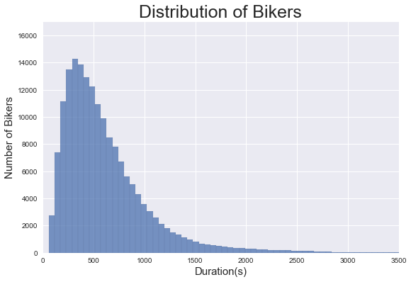

## Visualization 3: Correlation Plot of Age and Trip Duration

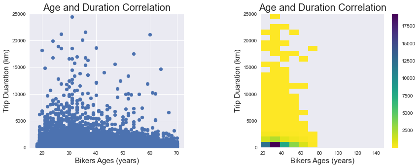

## Visualization 4: Grid Plot of Age, Time of Day and Distance Covered

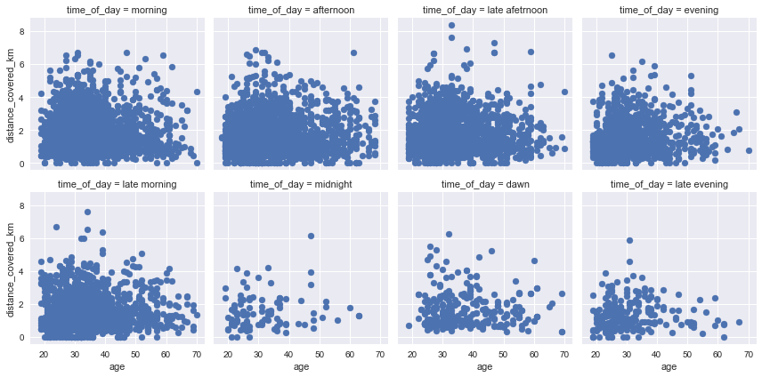